# Assessment

### Question 2

#### In Washington D.C., what were the top ten most frequently visited start stations?

```r
# Creating a new variable (start_station) that finds the frequency (count) of each value in Start.Station column.

start_station <- table(wash_2$Start.Station)
start_station
```

```
                                                               0
                                                  10th & E St NW
                                                             355
                                           10th & Florida Ave NW
                                                             254
                                                  10th & G St NW
                                                             291
                                                  10th & K St NW
                                                             434
                                             10th & Monroe St NE
                                                              80
                                                  10th & U St NW
                                                             460
                                   10th St & Constitution Ave NW
                                                             478
                                     10th St & L'Enfant Plaza SW
                                                             167
                                                  11th & F St NW
                                                             280
                                             11th & Girard St NW
                                                              51
                                                  11th & H St NE
                                                             237
                                             11th & Kenyon St NW
                                                             421
                                                  11th & M St NW
                                                             529
                                                  11th & O St NW
                                                             364
                                                  11th & S St NW
                                                             303
                                             12th & Army Navy Dr
                                                             130
                                             12th & Irving St NE
                                                              83
                                                  12th & L St NW
                                                             332
                                             12th & Newton St NE
                                                              49
                                                  12th & U St NW
```

[output cut: 900 more lines]

```
                                                             133
                                        Windham Ln & Amherst Ave
                                                               9
                                Wisconsin Ave & Brandywine St NW
                                                              61
                                   Wisconsin Ave & Ingomar St NW
                                                              39
                                    Wisconsin Ave & Newark St NW
                                                             200
                                         Wisconsin Ave & O St NW
                                                             309
                                    Woodmont Ave & Strathmore St
                                                              58
                                      Yuma St & Tenley Circle NW
                                                              57
```

```r
# Passing in start_station to find the top ten most frequented starting stations.

top_startstation <- head(sort(start_station, decreasing=TRUE),n=10)
top_startstation
```

```
                      Columbus Circle / Union Station
                                                 1700
                                     Lincoln Memorial
                                                 1546
                            Jefferson Dr & 14th St SW
                                                 1488
                 Massachusetts Ave & Dupont Circle NW
                                                 1219
                                   Jefferson Memorial
                                                 1068
                                       15th & P St NW
                                                 1040
Smithsonian-National Mall / Jefferson Dr & 12th St SW
                                                 1010
          Henry Bacon Dr & Lincoln Memorial Circle NW
                                                  910
                               4th St & Madison Dr NW
                                                  894
  Eastern Market Metro / Pennsylvania Ave & 7th St SE
                                                  823
```

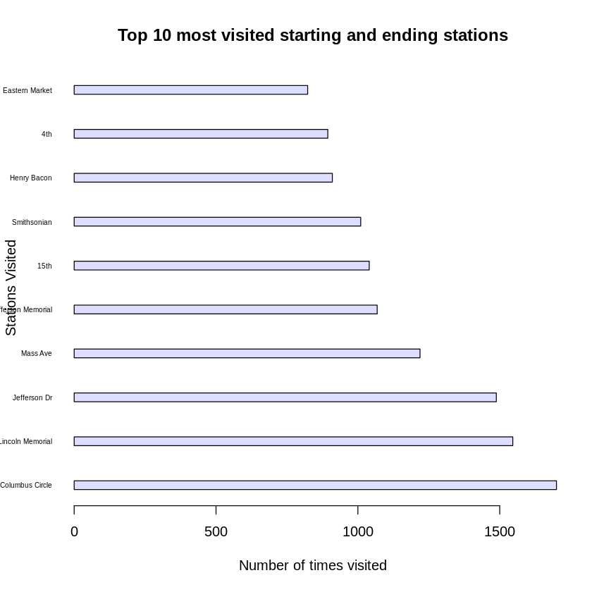

```r
# Passing in the top_startstation variable and plotting the top ten most visited starting stations.

barplot(top_startstation,
        space=4,
        horiz=TRUE,
        col="#DDDDFF",
        border="#000000",
        main='Top 10 most visited starting and ending stations',
        xlab="Number of times visited",
        ylab="Stations Visited",
        names.arg=c("Columbus Circle", "Lincoln Memorial","Jefferson Dr", "Mass Ave", "Jefferson Memorial","15th","Smithsonian",
                       "Henry Bacon", "4th", "Eastern Market"),
        las=1,
        cex.names=0.5)
```

```r
mean(top_startstation)
```

1169.8

```r
median(top_startstation)
```

1054

**Summary of the top ten more frequented starting stations**

As we can see above in the bar plot, the top station to be visited was Columbus Circle. It was visited more than double the amount of times that the Eastern Market station was visited, even though it was still top ten! We can also see that from the top ten most visited stations, the average number of times that a station was visited was ~1170 times. The median is not far off, with 1054 being right in the middle.

Columbus Circle being visited the most would make sense, as it is right next to Union Station, which brings in people from nearby Virginia, Maryland, and the outskirts of Washington D.C. People are starting their day getting off at Union Station and grabbing a bike to go head to work and to visit the city when from out of town.

### Question 3

#### For all datasets, did people who were subscribed to the bike share program travel more than those who were not subscribed?

Note: To answer this question I need to combine all datasets. However, in New York and Chicago, the 'Gender' and 'Birth.Year' columns are included, where as in Washington they are not. Since these columns are not relevant here, I will be dropping those columns first, and then combining with Washington.

```r
# Making a copy of the ny_chi dataset as not to mess up the original dataframe I already created.

drop_nychi <- data.frame(ny_chi)
head(drop_nychi)
```

| X | Start.Time | End.Time | Trip.Duration | Start.Station | End.Station | User.Type | Gender | Birth.Year |
| --- | --- | --- | --- | --- | --- | --- | --- | --- |
| 5688089 | 2017-06-11 14:55:05 | 2017-06-11 15:08:21 | 13 | Suffolk St & Stanton St | W Broadway & Spring St | Subscriber | Male | 1998 |
| 4096714 | 2017-05-11 15:30:11 | 2017-05-11 15:41:43 | 12 | Lexington Ave & E 63 St | 1 Ave & E 78 St | Subscriber | Male | 1981 |
| 2173887 | 2017-03-29 13:26:26 | 2017-03-29 13:48:31 | 22 | 1 Pl & Clinton St | Henry St & Degraw St | Subscriber | Male | 1987 |
| 3945638 | 2017-05-08 19:47:18 | 2017-05-08 19:59:01 | 12 | Barrow St & Hudson St | W 20 St & 8 Ave | Subscriber | Female | 1986 |
| 6208972 | 2017-06-21 07:49:16 | 2017-06-21 07:54:46 | 5 | 1 Ave & E 44 St | E 53 St & 3 Ave | Subscriber | Male | 1992 |
| 1285652 | 2017-02-22 18:55:24 | 2017-02-22 19:12:03 | 17 | State St & Smith St | Bond St & Fulton St | Subscriber | Male | 1986 |

```r
# Dropping 'Gender' and 'Birth.Year' columns.

drop_nychi <- subset(drop_nychi, select = -c(Gender, Birth.Year))
head(drop_nychi)
```

| X | Start.Time | End.Time | Trip.Duration | Start.Station | End.Station | User.Type |
| --- | --- | --- | --- | --- | --- | --- |
| 5688089 | 2017-06-11 14:55:05 | 2017-06-11 15:08:21 | 13 | Suffolk St & Stanton St | W Broadway & Spring St | Subscriber |
| 4096714 | 2017-05-11 15:30:11 | 2017-05-11 15:41:43 | 12 | Lexington Ave & E 63 St | 1 Ave & E 78 St | Subscriber |
| 2173887 | 2017-03-29 13:26:26 | 2017-03-29 13:48:31 | 22 | 1 Pl & Clinton St | Henry St & Degraw St | Subscriber |
| 3945638 | 2017-05-08 19:47:18 | 2017-05-08 19:59:01 | 12 | Barrow St & Hudson St | W 20 St & 8 Ave | Subscriber |
| 6208972 | 2017-06-21 07:49:16 | 2017-06-21 07:54:46 | 5 | 1 Ave & E 44 St | E 53 St & 3 Ave | Subscriber |
| 1285652 | 2017-02-22 18:55:24 | 2017-02-22 19:12:03 | 17 | State St & Smith St | Bond St & Fulton St | Subscriber |

Note: I'm going to fix the 'Trip.Duration' column (Dividing by 60 and rounding to convert to minutes instead of seconds). I won't be using it but I want to keep all columns clean before merging.

```r
# Converting the 'Trip.Duration' column to minutes by divding by 60.

wash_2$Trip.Duration <- wash_2$Trip.Duration/60
head(wash_2)
```

| X | Start.Time | End.Time | Trip.Duration | Start.Station | End.Station | User.Type |
| --- | --- | --- | --- | --- | --- | --- |
| 1621326 | 2017-06-21 08:36:34 | 2017-06-21 08:44:43 | 8.151100 | 14th & Belmont St NW | 15th & K St NW | Subscriber |
| 482740 | 2017-03-11 10:40:00 | 2017-03-11 10:46:00 | 6.709150 | Yuma St & Tenley Circle NW | Connecticut Ave & Yuma St NW | Subscriber |
| 1330037 | 2017-05-30 01:02:59 | 2017-05-30 01:13:37 | 10.620850 | 17th St & Massachusetts Ave NW | 5th & K St NW | Subscriber |
| 665458 | 2017-04-02 07:48:35 | 2017-04-02 08:19:03 | 30.455683 | Constitution Ave & 2nd St NW/DOL | M St & Pennsylvania Ave NW | Customer |
| 1481135 | 2017-06-10 08:36:28 | 2017-06-10 09:02:17 | 25.823783 | Henry Bacon Dr & Lincoln Memorial Circle NW | Maine Ave & 7th St SW | Subscriber |
| 1148202 | 2017-05-14 07:18:18 | 2017-05-14 07:24:56 | 6.633333 | 1st & K St SE | Eastern Market Metro / Pennsylvania Ave & 7th St SE | Subscriber |

```r
# Rounding the 'Trip.Duration' column.

wash_2$Trip.Duration <- round(wash_2$Trip.Duration)
head(wash_2)
```

| X | Start.Time | End.Time | Trip.Duration | Start.Station | End.Station | User.Type |
| --- | --- | --- | --- | --- | --- | --- |
| 1621326 | 2017-06-21 08:36:34 | 2017-06-21 08:44:43 | 8 | 14th & Belmont St NW | 15th & K St NW | Subscriber |
| 482740 | 2017-03-11 10:40:00 | 2017-03-11 10:46:00 | 7 | Yuma St & Tenley Circle NW | Connecticut Ave & Yuma St NW | Subscriber |
| 1330037 | 2017-05-30 01:02:59 | 2017-05-30 01:13:37 | 11 | 17th St & Massachusetts Ave NW | 5th & K St NW | Subscriber |
| 665458 | 2017-04-02 07:48:35 | 2017-04-02 08:19:03 | 30 | Constitution Ave & 2nd St NW/DOL | M St & Pennsylvania Ave NW | Customer |
| 1481135 | 2017-06-10 08:36:28 | 2017-06-10 09:02:17 | 26 | Henry Bacon Dr & Lincoln Memorial Circle NW | Maine Ave & 7th St SW | Subscriber |
| 1148202 | 2017-05-14 07:18:18 | 2017-05-14 07:24:56 | 7 | 1st & K St SE | Eastern Market Metro / Pennsylvania Ave & 7th St SE | Subscriber |

```r
# Merging all city tables.

allcity_data <- rbind(drop_nychi, wash_2)
allcity_data[sample(nrow(allcity_data), 7), ]
```

|  | X | Start.Time | End.Time | Trip.Duration | Start.Station | End.Station | User.Type |
| --- | --- | --- | --- | --- | --- | --- | --- |
| 59477 | 228302 | 2017-02-20 17:34:37 | 2017-02-20 17:43:17 | 9 | Oak Park Ave & South Blvd | Oak Park Ave & Harrison St | Subscriber |
| 74273 | 557821 | 2017-03-23 07:26:00 | 2017-03-23 07:30:00 | 4 | 1st & D St SE | M St & New Jersey Ave SE | Subscriber |
| 27144 | 4956863 | 2017-05-29 14:19:00 | 2017-05-29 14:23:54 | 5 | Lewis Ave & Kosciuszko St | Marcy Ave & Lafayette Ave | Subscriber |
| 23580 | 6807573 | 2017-06-30 19:16:44 | 2017-06-30 19:23:08 | 6 | Berkeley Pl & 7 Ave | 10 St & 5 Ave | Subscriber |
| 35009 | 6737026 | 2017-06-29 17:51:31 | 2017-06-29 18:07:29 | 16 | Broadway & W 41 St | W 70 St & Amsterdam Ave | Subscriber |
| 377341 | 1447281 | 2017-06-08 05:09:56 | 2017-06-08 05:24:33 | 15 | 14th & D St NW / Ronald Reagan Building | 3rd St & Pennsylvania Ave SE | Subscriber |
| 34186 | 1928164 | 2017-03-20 19:39:30 | 2017-03-20 19:44:27 | 5 | Norfolk St & Broome St | Henry St & Grand St | Subscriber |

```r
# Double checking to make sure all rows that are merged are present.

nrow(allcity_data)
```

145176

```r
# Omitting all 'NA' values.

allcity_data <- na.omit(allcity_data)
```

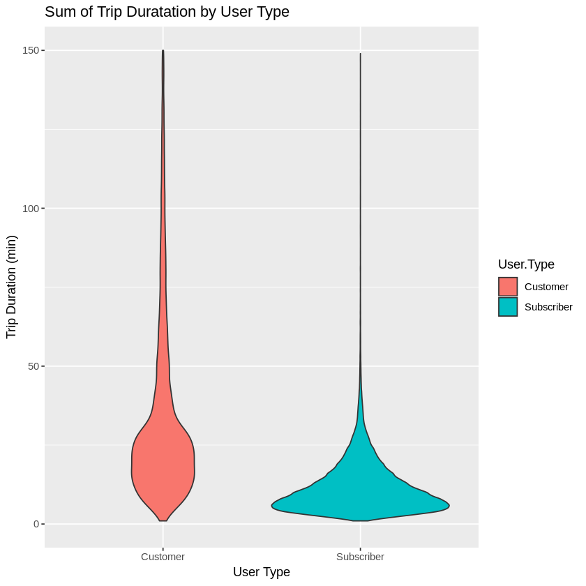

```r
ggplot(allcity_data, aes(x=User.Type, y=Trip.Duration, fill=User.Type)) +
  geom_violin() +
  scale_y_continuous(limits= c(0,150)) +
  ggtitle("Sum of Trip Duratation by User Type") +
  xlab("User Type") + ylab("Trip Duration (min)")
```

Note: The graph above is the zoomed in version of the plot below. The plot below is the original violin chart. Because the trip durations are congragated below 200 minutes, I wanted to show the zoomed in version as well.

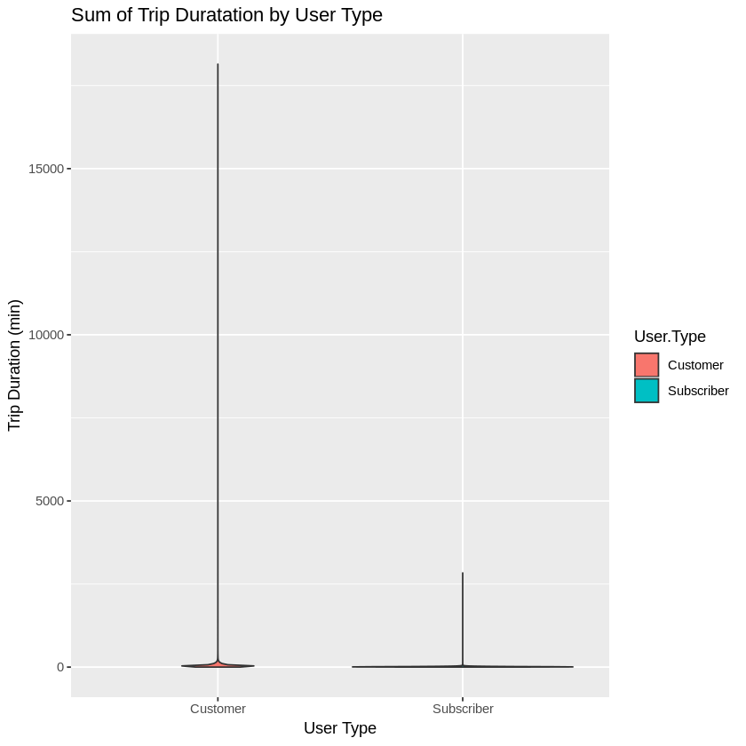

```r
ggplot(allcity_data, aes(x=User.Type, y=Trip.Duration, fill=User.Type)) +
  geom_violin() +
  ggtitle("Sum of Trip Duratation by User Type") +
  xlab("User Type") + ylab("Trip Duration (min)")
```

```r
summary(allcity_data$Trip.Duration)
```

```
    Min.  1st Qu.   Median     Mean  3rd Qu.     Max.
    1.00     6.00    11.00    17.64    19.00 18144.00
```

**Summary of Trip Duration by Subscriber Type**

I chose to do two graphs to answer this question. Just like in my first questions, showing the data in it's original form was skewed because a few people didn't turn their bikes in for days on end, this is represented as 'max' in the summary statistics. The 'tail' of the violin was much larger than it should be because of this. I chose to zoom in on the main portion of users and trip duration, which is depecited in the first graph.

```r
system('python -m nbconvert Explore_bikeshare_data.ipynb')
```